# chapter4

### Scaling and standardization

Because these variables have really different ranges and distributions, it would be a good idea to scale them so that all of them are centered in a same way. The command `scale()` calculates the means and standard deviations of the variables and uses them to standardize them. This is what our data (named as `boston_scaled`) looks like after scaling:

```r
boston_scaled <- as.data.frame(scale(boston))
summary(boston_scaled)
```

```
##       crim                 zn               indus
##  Min.   :-0.419367   Min.   :-0.48724   Min.   :-1.5563
##  1st Qu.:-0.410563   1st Qu.:-0.48724   1st Qu.:-0.8668
##  Median :-0.390280   Median :-0.48724   Median :-0.2109
##  Mean   : 0.000000   Mean   : 0.00000   Mean   : 0.0000
##  3rd Qu.: 0.007389   3rd Qu.: 0.04872   3rd Qu.: 1.0150
##  Max.   : 9.924110   Max.   : 3.80047   Max.   : 2.4202
##       chas              nox                rm               age
##  Min.   :-0.2723   Min.   :-1.4644   Min.   :-3.8764   Min.   :-2.3331
##  1st Qu.:-0.2723   1st Qu.:-0.9121   1st Qu.:-0.5681   1st Qu.:-0.8366
##  Median :-0.2723   Median :-0.1441   Median :-0.1084   Median : 0.3171
##  Mean   : 0.0000   Mean   : 0.0000   Mean   : 0.0000   Mean   : 0.0000
##  3rd Qu.:-0.2723   3rd Qu.: 0.5981   3rd Qu.: 0.4823   3rd Qu.: 0.9059
##  Max.   : 3.6648   Max.   : 2.7296   Max.   : 3.5515   Max.   : 1.1164
##       dis               rad               tax             ptratio
##  Min.   :-1.2658   Min.   :-0.9819   Min.   :-1.3127   Min.   :-2.7047
##  1st Qu.:-0.8049   1st Qu.:-0.6373   1st Qu.:-0.7668   1st Qu.:-0.4876
##  Median :-0.2790   Median :-0.5225   Median :-0.4642   Median : 0.2746
##  Mean   : 0.0000   Mean   : 0.0000   Mean   : 0.0000   Mean   : 0.0000
##  3rd Qu.: 0.6617   3rd Qu.: 1.6596   3rd Qu.: 1.5294   3rd Qu.: 0.8058
##  Max.   : 3.9566   Max.   : 1.6596   Max.   : 1.7964   Max.   : 1.6372
##      black             lstat              medv
##  Min.   :-3.9033   Min.   :-1.5296   Min.   :-1.9063
##  1st Qu.: 0.2049   1st Qu.:-0.7986   1st Qu.:-0.5989
##  Median : 0.3808   Median :-0.1811   Median :-0.1449
##  Mean   : 0.0000   Mean   : 0.0000   Mean   : 0.0000
##  3rd Qu.: 0.4332   3rd Qu.: 0.6024   3rd Qu.: 0.2683
##  Max.   : 0.4406   Max.   : 3.5453   Max.   : 2.9865
```

Now mean of all variables is 0. This way they are much more comparable since they are centered same way.

Next we’ll make a new variable also called `crime` which is actually a categorical variable that is made from the original `crime`. The new variable uses the quantiles from the original variable as its break points. After this, the old `crime` will be dropped and we’ll use the new one.

```r
bins <- quantile(boston_scaled$crim)
bins
```

```
##           0%          25%          50%          75%         100%
## -0.419366929 -0.410563278 -0.390280295  0.007389247  9.924109610
```

```r
crime <- cut(boston_scaled$crim, breaks = bins , label = c("low", "med_low", "med_high", "high"), include.lowest = TRUE)
table(crime)
```

```
## crime
##      low  med_low med_high     high
##      127      126      126      127
```

```r
boston_scaled <- dplyr::select(boston_scaled, -crim)

boston_scaled <- data.frame(boston_scaled, crime)
```

This is all the data manipulation we will need! Now it’s time for train and test sets.

### Test and train data sets

In machine learning it is important that we use different data for training the model and when testing its goodness. If this wasn’t done, the model would probably overfit or not be suitable for other datasets in some other way. That is why we will split our current dataset. Usually the amount of data that is given for test set is around 10-40%, usually 20-30%. We will use 20% so that we have enough data for training:

```r
sample_size <- floor(0.80 * nrow(boston_scaled))
set.seed(42)
train_indices <- sample(seq_len(nrow(boston_scaled)), size = sample_size)

train <- boston_scaled[train_indices, ]
test <- boston_scaled[-train_indices, ]
```

After the splitting we are ready for some modelling.

### LDA

This time we are going to use linear discriminant analysis that is suitable for classification (so we know the groups before fitting the model!) tasks. Our categorical variable, which defines the class, is the one that we created in previous part. It means that it is going to be our target variable while the other variables will be the predictors. Let’s fit the model and see what kind of results we are getting:

```r
lda.fit <- lda(crime ~., data = train)


lda.fit
```

```
## Call:
## lda(crime ~ ., data = train)
##
## Prior probabilities of groups:
##       low   med_low  med_high      high
## 0.2574257 0.2351485 0.2376238 0.2698020
##
## Group means:
##                  zn      indus        chas        nox         rm
## low       0.8493721 -0.8697340 -0.12090214 -0.8619406  0.4323810
## med_low  -0.0476367 -0.3616877 -0.02367011 -0.6349827 -0.1030773
## med_high -0.3871935  0.1739756  0.17879700  0.3432386  0.1244914
## high     -0.4872402  1.0149946 -0.05560795  1.0712213 -0.3889671
##                 age        dis        rad        tax     ptratio
## low      -0.8500445  0.7994565 -0.6892330 -0.7415431 -0.42271224
## med_low  -0.4750741  0.5060898 -0.5345735 -0.5367257 -0.06065883
## med_high  0.4038831 -0.3601235 -0.4207972 -0.3145182 -0.19982809
## high      0.8033749 -0.8519341  1.6596029  1.5294129  0.80577843
##               black       lstat        medv
## low       0.3877799 -0.77386763  0.51551359
## med_low   0.3228171 -0.17438217  0.03340113
## med_high  0.1429415 -0.01151508  0.17946160
## high     -0.8353394  0.89641301 -0.70881495
##
## Coefficients of linear discriminants:
##                 LD1         LD2         LD3
## zn       0.09823274  0.50670671 -1.08729424
## indus    0.03111473 -0.23288590  0.48589410
## chas    -0.10543021 -0.03031872  0.11827513
## nox      0.24893075 -0.99359892 -0.97953460
## rm      -0.08342747 -0.12461232 -0.13456351
## age      0.31441545 -0.35506917 -0.21656507
## dis     -0.12038125 -0.23973804  0.61335376
## rad      3.56444799  1.13916235  0.09948690
## tax      0.20471600 -0.08489325  0.16722950
## ptratio  0.16215783 -0.09228254 -0.21123315
## black   -0.12925677  0.02162516  0.10894040
## lstat    0.12271248 -0.19098632  0.59411810
## medv     0.13413556 -0.42899275  0.01244778
##
## Proportion of trace:
##    LD1    LD2    LD3
## 0.9641 0.0267 0.0092
```

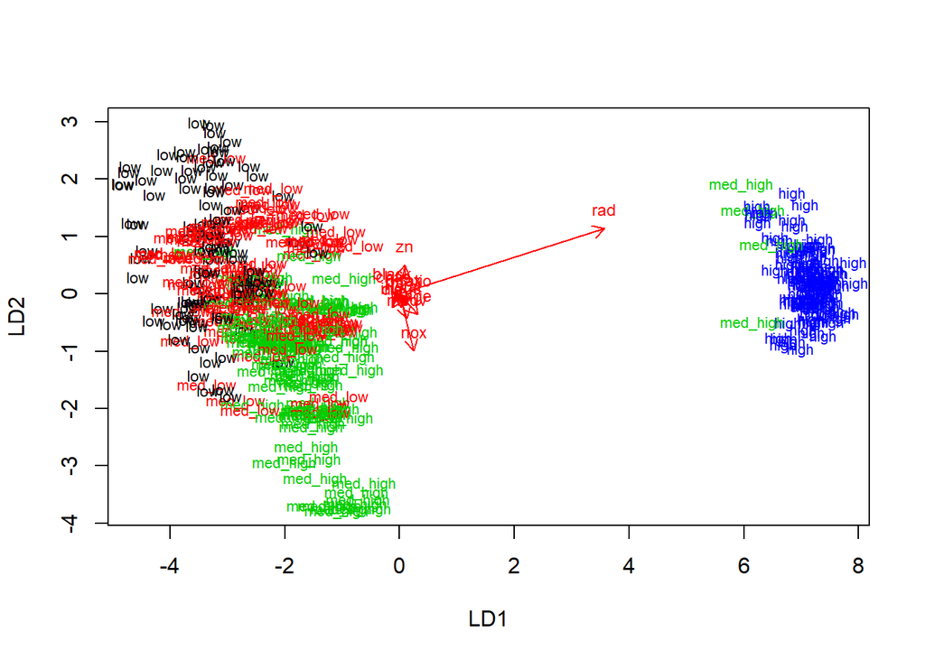

```r
# the function for lda biplot arrows
lda.arrows <- function(x, myscale = 1, arrow_heads = 0.1, color = "red", tex = 0.75, choices = c(1,2)){
  heads <- coef(x)
  arrows(x0 = 0, y0 = 0,
         x1 = myscale * heads[,choices[1]],
         y1 = myscale * heads[,choices[2]], col=color, length = arrow_heads)
  text(myscale * heads[,choices], labels = row.names(heads),
       cex = tex, col=color, pos=3)
}

classes <- as.numeric(train$crime)

plot(lda.fit, col = classes, pch = classes, dimen = 2)
lda.arrows(lda.fit, myscale = 1)
```

From the model summary we can see the prior probabilites for each group. All groups seem to have almost same probability (because we used the quantiles as break points) so there is no dominant group. Then we can see some group means and coefficients for the redictors. LD1, LD2 and LD3 are the linear discriminants and because we have four groups we have three LDs. Proportion of trace tells how much the discriminant explains the variance between groups. The first one has clearly the highest explanation rate.

The plot of the linear discriminants can show us how the groups are scattered and how the predictors impact on the model. The arrow that represents `rad` is significantly longer than others so it has the highest impact, and it is pointing to group *high*. The arrow of variable `nox` is also a bit longer than others. We can see that the group *high* is completely separated from others, though there are few lost *med-high* values.

### Validation

Now that we have trained our model, we need to test it to see how well it actually works. We’ll use the model to the test data and check which group it chooses for each data point. Then we’ll compare the results for the real values to see how good the model is for predicting the target variable `crime`. If the model does not predict well, it needs to be tuned and then tested again.

```r
correct_classes <- test$crime
test <- dplyr::select(test, -crime)

lda.pred <- predict(lda.fit, newdata = test)

# cross tabulate the results
table(correct = correct_classes, predicted =  lda.pred$class)
```

```
##           predicted
## correct    low med_low med_high high
##   low       18       4        1    0
##   med_low    5      12       14    0
##   med_high   1       5       22    2
##   high       0       0        1   17
```

### K-means and grouping

After classification we try clustering. As mentioned earlier, now we do not know the groups in which we are trying to divide our data. We’ll use the scaled `boston` data that is called in this case `boston2`. After scaling we calculate the distances between the observations to know how they deviate:

```r
boston2 <- Boston
boston2_scaled <- scale(boston2)

boston2_dist <- dist(boston2_scaled)
summary(boston2_dist)
```

```
##    Min. 1st Qu.  Median    Mean 3rd Qu.    Max.
##  0.1343  3.4625  4.8241  4.9111  6.1863 14.3970
```

The summary shows the statistics of the distances. It seems that the deviation is quite much even though the data is scaled.

For clustering we are going to use k-means algorithm that uses euclidean distances to group data points. After choosing the number of groups, the algorithm calculates centroids and divides data points into groups by the closest centroid. A tricky part is to choose optimal number of groups: too many groups means overfit and too little does not really give any information. We’ll start with five groups:

```r
kms <- kmeans(boston2_scaled, centers = 5)
kms
```

```
## K-means clustering with 5 clusters of sizes 92, 124, 97, 34, 159
##
## Cluster means:
##         crim         zn      indus       chas        nox         rm
## 1 -0.3988237  1.6016220 -1.0687491 -0.2295345 -0.8434630  1.1056741
## 2  1.1156495 -0.4872402  1.0149946 -0.2723291  0.9916473 -0.4276828
## 3 -0.3264152 -0.4817148  0.6467048 -0.2723291  0.4661492 -0.4933328
## 4 -0.1985497 -0.2602436  0.2799956  3.6647712  0.3830784  0.2756681
## 5 -0.3977094 -0.1972128 -0.6275763 -0.2723291 -0.6516151 -0.0642062
##          age        dis          rad        tax     ptratio       black
## 1 -0.9530816  0.9895824 -0.596136078 -0.6403452 -1.03983483  0.34841822
## 2  0.7515952 -0.8170870  1.659602895  1.5294129  0.80577843 -0.81154619
## 3  0.7694858 -0.5767447 -0.601811492 -0.1635666  0.19053950  0.04851267
## 4  0.3721322 -0.4033382  0.001081444 -0.0975633 -0.39245849  0.17154271
## 5 -0.5836914  0.5027355 -0.582435812 -0.7015870 -0.05905952  0.36502559
```

[output cut: 76 more lines]

The k-means statistics tells for example cluster sizes and means. Cluster sizes differ a lot, the largest one is almost five times bigger than the smallest one. This might indicate that we have too many clusters. Sum of squares is a rough estimate of the model goodness. Our percentage is 56.4 which is not very good.

It would be good to try to optimize the number of groups that should be using in the custering. One way is to use sum of squares and especially the within cluster sum of squares. When there happens a sudden drop in that number we know that the optimal k is somewhere there. Let’s try to plot that so that we can visualize what was just explained:

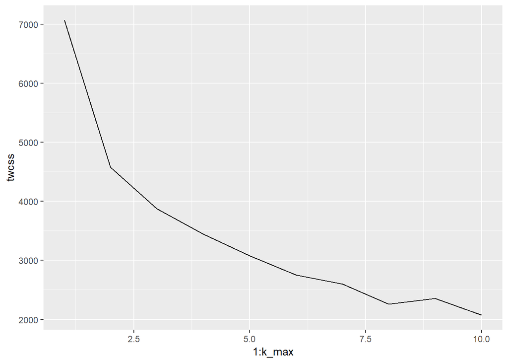

```r
k_max <- 10

twcss <- sapply(1:k_max, function(k){kmeans(boston2_scaled, k)$tot.withinss})

qplot(x = 1:k_max, y = twcss, geom = 'line')
```

Here we can see how the sum of squares change when used different number of clusters. It looks like the drop happens when k is two so we are going to use it this time.

Here are plotted all the variables with five clusters that we first used and then with two that was optimized:

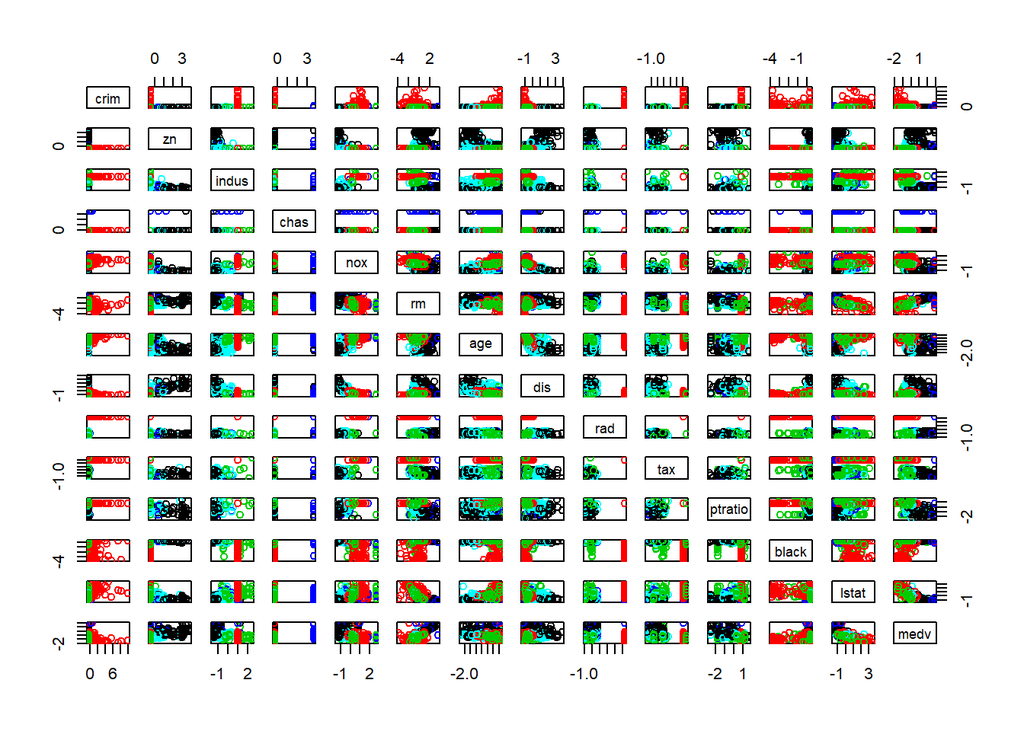

```r
kms2 <- kmeans(boston2_scaled, centers = 2)

pairs(boston2_scaled, col = kms$cluster)
```

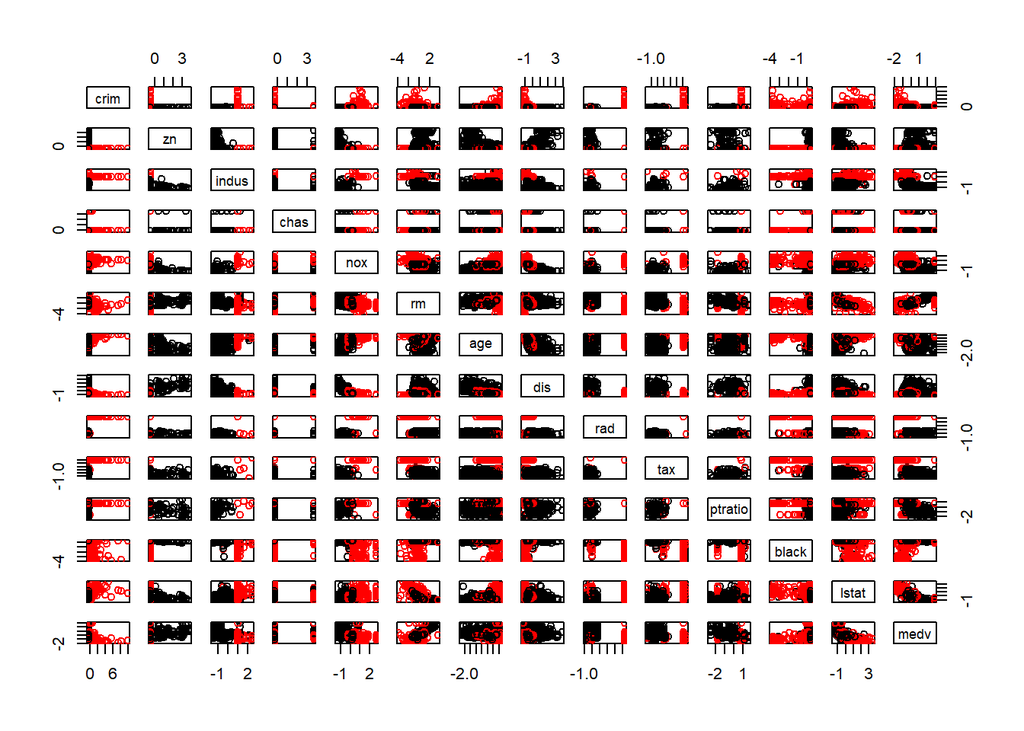

```r
pairs(boston2_scaled, col = kms2$cluster)
```

As we can se from the scatter plots, more groups did not really give us more information. With some other data the optimal number of groups can be much different and there could be seeing logic within groups much easier. It could be also interesting to use less variables to see how that would impact to this algorithm.